# Exploratory Data Analysis on Automobile Dataset

# display a distrubation of price

so this this distrubation is A "skewed right" distribution.in which the tail is on the right side.

A positive skewness indicates that the size of the right-handed tail is larger than the left-handed tail.

skewness affect on data: mean greater than the mode, median greater than the mode, mean greater than median,

Here we se that most of car price are in between 5000 to 20000 and there is rare cars which are expensive

The kurtosis parameter is a measure of the combined weight of the tails relative to the rest of the distribution.”

if kurtosis is positive than it shows a dataset with more weight in the tails.

```
This distribution has skew 1.795048816900581
This distribution has kurtosis 3.171943010610039
```

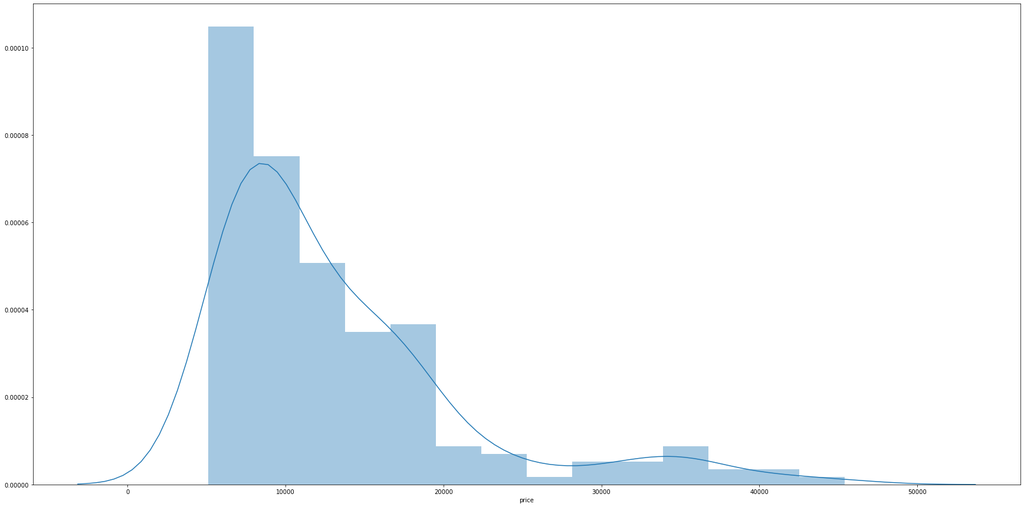

```python
sns.distplot(df['price'])
print('This distribution has skew', df['price'].skew())
print('This distribution has kurtosis', df['price'].kurt())
```

# Distrubation of length

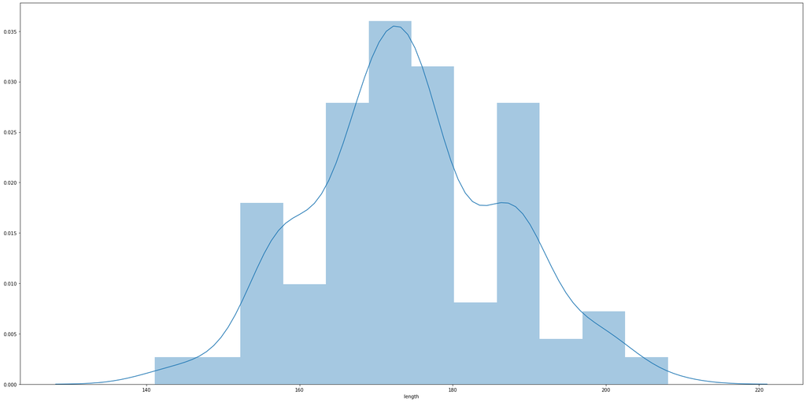

```python
sns.distplot(df['length'])
```

# distrubation of highway-mpg

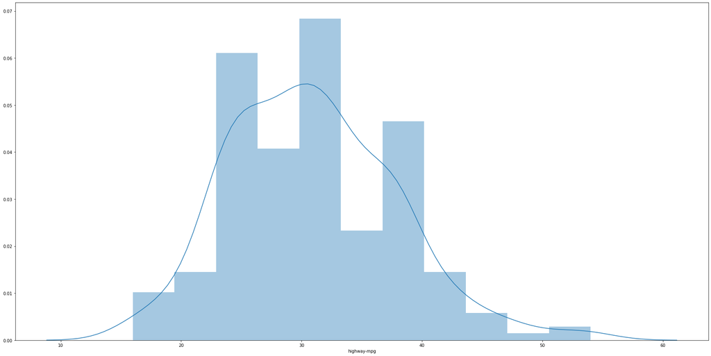

```python
sns.distplot(df['highway-mpg'])
```

# Scatter plot of price and engine size

The more the engine size the costlier the price is

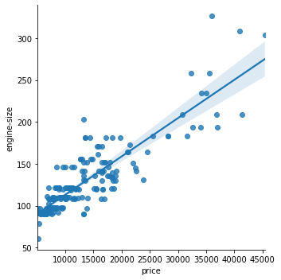

```python
sns.lmplot('price',"engine-size", df);
```

# Scatter plot of price and highway-mpg

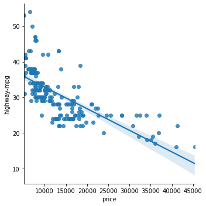

```python
sns.lmplot('price',"highway-mpg", df)
```

# Scatter plot of City and Highway MPG, Curb weight based on Make of the car

Heavier the Automobile less is the mileage for both City and Highway

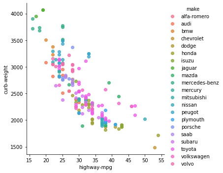

```python
sns.lmplot('highway-mpg',"curb-weight", df, hue="make",fit_reg=False)
```

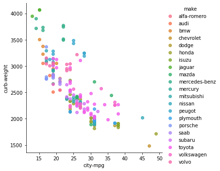

```python
sns.lmplot('city-mpg',"curb-weight", df, hue="make", fit_reg=False)
```

# Drive wheels and City MPG bar chart

```python
df.groupby('drive-wheels')['city-mpg'].mean()
```

```
drive-wheels
4wd    23.111111
fwd    28.316667
rwd    20.578947
Name: city-mpg, dtype: float64
```

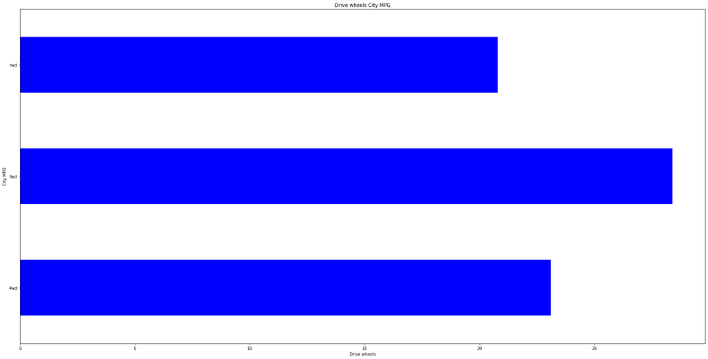

```python
df.groupby('drive-wheels')['city-mpg'].mean().plot(kind='barh', color = 'blue')
plt.title("Drive wheels City MPG")
plt.ylabel('City MPG')
plt.xlabel('Drive wheels');
```

# Drive wheels and Highway MPG bar chart

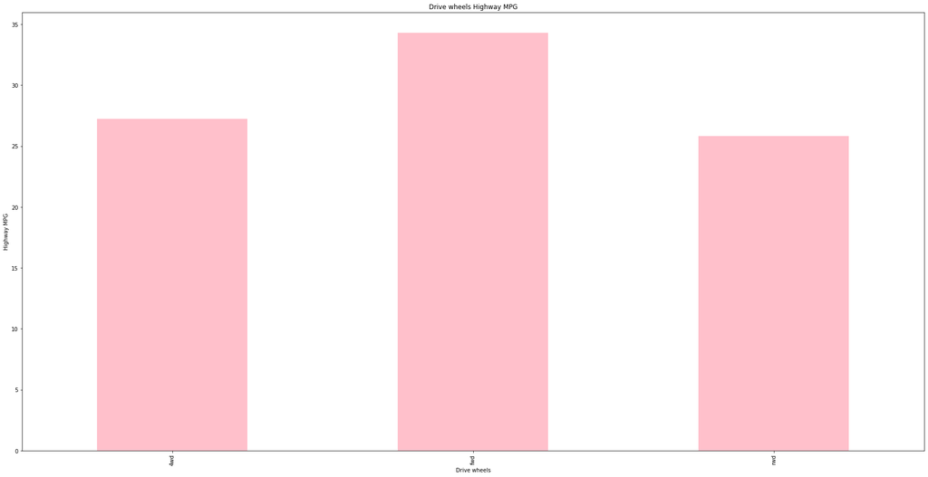

```python
df.groupby('drive-wheels')['highway-mpg'].mean().plot(kind='bar', color = 'pink');
plt.title("Drive wheels Highway MPG")
plt.ylabel('Highway MPG')
plt.xlabel('Drive wheels');
```

# Normalized losses based on body style and no. of doors

Findings: As we understand the normalized loss which is the average loss payment per insured vehicle is calculated with many features of the cars which includes body style and no. of doors. Normalized losses are distributed across different body style but the two door cars has more number of losses than the four door cars.

```python
pd.pivot_table(df,index=['body-style','num-of-doors'], values='normalized-losses')
```

| body-style | num-of-doors | normalized-losses |
| --- | --- | --- |
| convertible | two | 127.333333 |
| hardtop | two | 128.625000 |
| hatchback | four | 100.000000 |
|  | two | 135.750000 |
| sedan | ? | 135.000000 |
|  | four | 117.354430 |
|  | two | 137.800000 |
| wagon | four | 98.560000 |

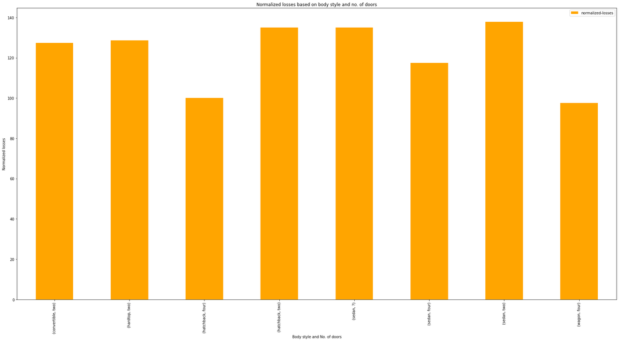

```python
pd.pivot_table(df,index=['body-style','num-of-doors'], values='normalized-losses').plot(kind='bar',color='orange')
plt.title("Normalized losses based on body style and no. of doors")
plt.ylabel('Normalized losses')
plt.xlabel('Body style and No. of doors');
```